# Correlações dos Representantes no Twitter

Lívia Cavalcanti

## Olhando os dados de novo

```r
atividade = read_projectdata()
twitteiros <- atividade %>%
  filter(!is.na(seguidores))
tail(twitteiros)
```

```
## # A tibble: 6 x 19
##   id_parlamentar casa  nome_eleitoral partido UF    twitter seguidores
##   <chr>          <chr> <chr>          <chr>   <chr> <chr>        <dbl>
## 1 5535           sena… TELMÁRIO MOTA  PROS    RR    Telmar…       5539
## 2 5899           sena… VANDERLAN CAR… PP      GO    Vander…       7065
## 3 5748           sena… VENEZIANO VIT… PSB     PB    venezi…      16045
## 4 1173           sena… WELLINGTON FA… PR      MT    sen_we…       5507
## 5 5411           sena… WEVERTON       PDT     MA    wevert…       7821
## 6 3806           sena… ZEQUINHA MARI… PSC     PA    Zequin…        126
## # ... with 12 more variables: segue <dbl>, n_proprio <dbl>,
## #   n_retweet <dbl>, engaj_total <dbl>, engaj_total_proprio <dbl>,
## #   engaj_total_retweet <dbl>, engaj_mediano <dbl>,
## #   engaj_mediano_proprio <dbl>, engaj_mediano_retweet <dbl>,
## #   engaj_max <dbl>, engaj_max_proprio <dbl>, engaj_max_retweet <dbl>
```

## Quanto mais o representante segue mais ele retuíta?

```r
twitteiros  %>%
  summarise(pearson = cor(segue, n_retweet, method = "pearson"),
            spearman = cor(segue, n_retweet, method = "spearman"))
```

```
## # A tibble: 1 x 2
##   pearson spearman
##     <dbl>    <dbl>
## 1  0.0553    0.332
```

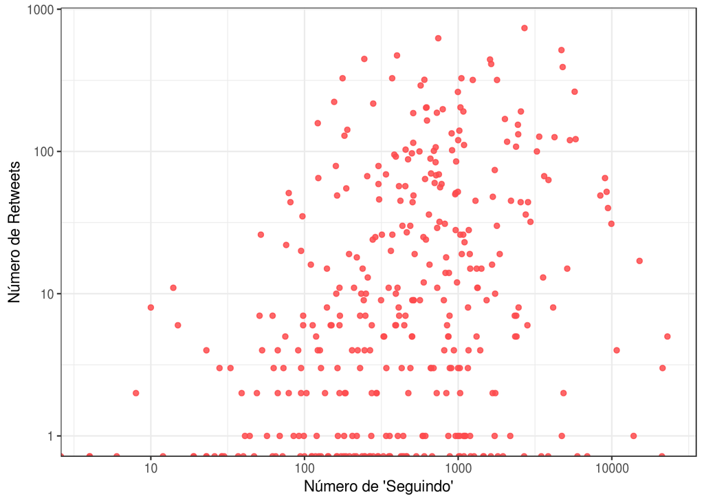

```r
twitteiros %>%
  ggplot(aes(segue, n_retweet)) +
  geom_point(color="#FC4C4E", alpha=.85) +
  scale_x_log10() +
  scale_y_log10() +
  labs(y="Número de Retweets", x = "Número de 'Seguindo'")
```

Não há correlação linear alguma, segundo Pearson, entre a quantidade de perfis que o respresentante segue e a quantidade de retuítes que ele faz. Mas há uma correlação monotônica positiva entre essas duas variáveis, ou seja, o crescimento de um valor leva ao crescimento do outro de alguma forma não-linear, ainda que fracamente. Com isso, mesmo modificando a escala pouca organização nos dados é vista.

## Além de seguir as pessoas interagem?

```r
twitteiros  %>%
  summarise(pearson = cor(seguidores, engaj_mediano, method = "pearson"),
            spearman = cor(seguidores, engaj_mediano, method = "spearman"))
```

```
## # A tibble: 1 x 2
##   pearson spearman
##     <dbl>    <dbl>
## 1   0.351    0.681
```

Como visto na prática, o total de seguidores não reage a todas as postagens. Ou seja, de modo geral, as reações aos tweets são menores do que a quantidade de seguidores. Mas quanto mais seguidores maior o número de retweets e likes. Essa relação pode ser modelada de forma mais fraca, linearmente falando, de acordo com o valor de Pearson, e, mais forte para o coeficiente de Spearman, ou seja, há uma relação não-linear para esse crescimento. No gráfico, pode-se ver que os dados estão bem dispostos não havendo pontos extremos fugindo à tendência geral. No máximo, um afastamento não muito expressivo, como dos três pontos na região central e na extrema direta do gráfico.

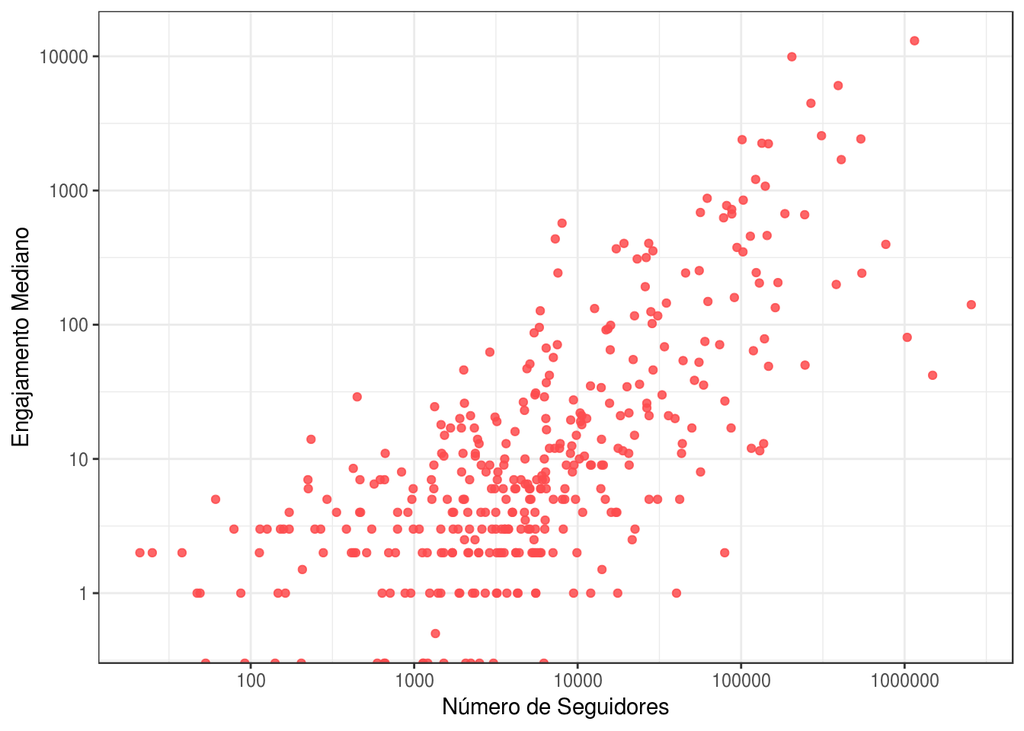

```r
twitteiros %>%
  ggplot(aes(seguidores, engaj_mediano)) +
  geom_point(color="#FC4C4E", alpha=.85) +
  scale_x_log10() +
  scale_y_log10() +
  labs(x = "Número de Seguidores", y = "Engajamento Mediano")
```